# Homework 9

Luis Alvarez

2026-02-10

## Instructions

Answer the following questions and complete the exercises in RMarkdown. Please embed all of your code and push your final work to your repository. Your final lab report should be organized, clean, and run free from errors. Remember, you must remove the `#` for the included code chunks to run. Be sure to add your name to the author header above.

Make sure to use the formatting conventions of RMarkdown to make your report neat and clean!

## Load the libraries

```r
library(tidyverse)
library(janitor)
```

## Data

For this homework, we will use a data set compiled by the Office of Environment and Heritage in New South Whales, Australia. It contains the enterococci counts in water samples obtained from Sydney beaches as part of the Beachwatch Water Quality Program. *Enterococci* are bacteria common in the intestines of mammals; they are rarely present in clean water. So, *Enterococci* values are a measurement of pollution. `cfu` stands for colony forming units and measures the number of viable bacteria in a sample [cfu](https://en.wikipedia.org/wiki/Colony-forming_unit).

This homework loosely follows the tutorial of [R Ladies Sydney](https://rladiessydney.org/). If you get stuck, check it out!

1. Start by loading the data `sydneybeaches`. Do some exploratory analysis to get an idea of the data structure.

```r
sydbeaches <- read_csv("data/sydneybeaches.csv")
```

2. Are these data “tidy” per the definitions of the tidyverse? How do you know? Are they in wide or long format?

```r
#The data is not tidy as the data should be moved to a long format so that points like Site or Region are not considered data points.
```

3. We are only interested in the variables site, date, and enterococci_cfu_100ml. Make a new object focused on these variables only. Name the object `sydneybeaches_long`

```r
sydbeaches_long <- sydbeaches %>%
  select(Site,Date,`Enterococci (cfu/100ml)`)
```

4. Pivot the data such that the dates are column names and each beach only appears once (wide format). Name the object `sydneybeaches_wide`

```r
sydbeaches_wide <- sydbeaches_long %>%
  pivot_wider(names_from = "Date",
              values_from = "Enterococci (cfu/100ml)")
```

5. Pivot the data back so that the dates are data and not column names. #

```r
sydbeaches_wide %>%
  pivot_longer(-"Site",
  names_to = "Date",
  values_to = "Enterococci (cfu/100ml)")
```

```
## # A tibble: 3,784 × 3
##    Site           Date       `Enterococci (cfu/100ml)`
##    <chr>          <chr>                          <dbl>
##  1 Clovelly Beach 02/01/2013                        19
##  2 Clovelly Beach 06/01/2013                         3
##  3 Clovelly Beach 12/01/2013                         2
##  4 Clovelly Beach 18/01/2013                        13
##  5 Clovelly Beach 30/01/2013                         8
##  6 Clovelly Beach 05/02/2013                         7
##  7 Clovelly Beach 11/02/2013                        11
##  8 Clovelly Beach 23/02/2013                        97
##  9 Clovelly Beach 07/03/2013                         3
## 10 Clovelly Beach 25/03/2013                         0
## # ℹ 3,774 more rows
```

6. We haven’t dealt much with dates yet, but separate the date into columns day, month, and year. Do this on the `sydneybeaches_long` data.

```r
sydbeaches_long2 <- sydbeaches_long %>%
  separate(Date, into = c("day", "month", "year"))
```

7. What is the average `enterococci_cfu_100ml` by year for each beach. Think about which data you will use- long or wide.

```r
sydbeaches_long2 %>%
  group_by(year,Site) %>%
  select(`Enterococci (cfu/100ml)`) %>%
  summarise(mean_en=mean(`Enterococci (cfu/100ml)`))
```

```
## # A tibble: 66 × 3
## # Groups:   year [6]
##    year  Site                    mean_en
##    <chr> <chr>                     <dbl>
##  1 2013  Bondi Beach               32.2
##  2 2013  Bronte Beach              26.8
##  3 2013  Clovelly Beach             9.28
##  4 2013  Coogee Beach              39.7
##  5 2013  Gordons Bay (East)        24.8
##  6 2013  Little Bay Beach         122.
##  7 2013  Malabar Beach            101.
##  8 2013  Maroubra Beach            47.1
##  9 2013  South Maroubra Beach      39.3
## 10 2013  South Maroubra Rockpool   96.4
## # ℹ 56 more rows
```

8. Make the output from question 7 easier to read by pivoting it to wide format.

```r
sydbeaches_wide2 <- sydbeaches_long2 %>%
  group_by(year,Site) %>%
  select(`Enterococci (cfu/100ml)`) %>%
  summarise(mean_en=mean(`Enterococci (cfu/100ml)`)) %>%
  pivot_wider(names_from = "Site",
              values_from = "mean_en")
```

9. What was the most polluted beach in 2013?

```r
sydbeaches_wide2 %>%
  filter(year=="2013")
```

```
## # A tibble: 1 × 12
## # Groups:   year [1]
##   year  `Bondi Beach` `Bronte Beach` `Clovelly Beach` `Coogee Beach`
##   <chr>         <dbl>          <dbl>            <dbl>          <dbl>
## 1 2013           32.2           26.8             9.28           39.7
## # ℹ 7 more variables: `Gordons Bay (East)` <dbl>, `Little Bay Beach` <dbl>,
## #   `Malabar Beach` <dbl>, `Maroubra Beach` <dbl>,
## #   `South Maroubra Beach` <dbl>, `South Maroubra Rockpool` <dbl>,
## #   `Tamarama Beach` <dbl>
```

```r
  #The most polutted was little bay beach
```

10. Explore the data! Do one analysis of your choice that includes a minimum of three lines of code.

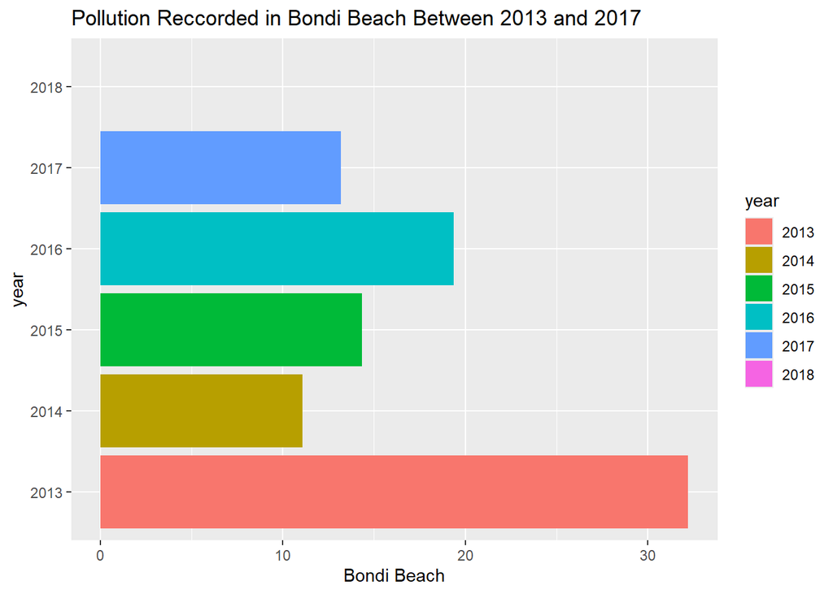

```r
sydbeaches_wide2 %>%
  ggplot(mapping = aes(x= `Bondi Beach`, y=year))+
  geom_col(mapping = aes(fill = year)) +
  labs(title = "Pollution Reccorded in Bondi Beach Between 2013 and 2017")
```

```r
#The most pollution recorded in bondi beach was in 2013
```

## Knit and Upload

Please knit your work as an .html file and upload to Canvas. Homework is due before the start of the next lab. No late work is accepted. Make sure to use the formatting conventions of RMarkdown to make your report neat and clean!